# Los Angeles Demographics Lab

## Race

The race data will first be prepared in order to create a dataset with readable racial groups and determining the share of each racial group.

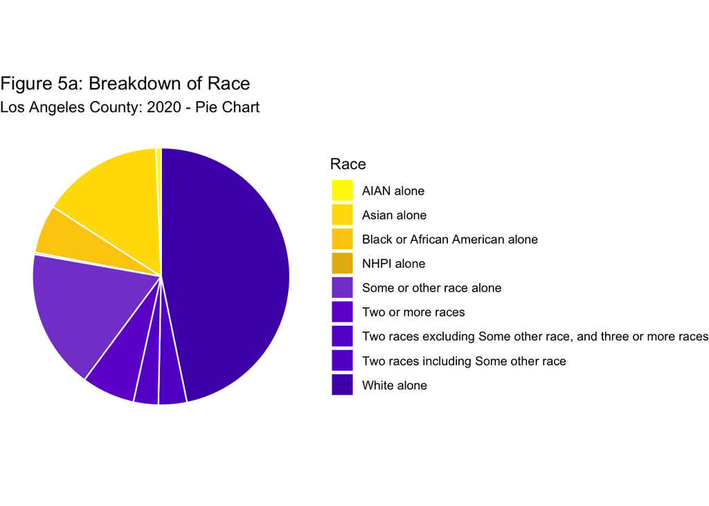

```r
la_race <- la_race %>%
  mutate(tot_pop = 13211027)  %>% filter(variable != "B02001_001")

rgroups <- c("White alone", "Black or African American alone", "AIAN alone", "Asian alone", "NHPI alone", "Some or other race alone", "Two or more races", "Two races including Some other race", "Two races excluding Some other race, and three or more races")

la_race <- la_race %>%
  mutate(race_groups = rep(rgroups, length(unique(name))))

la_race <- la_race %>%
  mutate(pop_share = estimate/tot_pop) %>%
  select(estimate, race_groups, pop_share)

ggplot(la_race, aes(x="", y=pop_share, fill=race_groups)) +
  geom_bar(stat="identity", width=1, color="white") +
  coord_polar("y", start=0) +
  theme_void() +
  scale_fill_manual(values = palette9,
                    name = "Race") +
    labs(subtitle="Los Angeles County: 2020 - Pie Chart",
       title= "Figure 5a: Breakdown of Race")
```

Figure 5a finds that almost 50% of Los Angeles County is White alone, followed by some or other race alone and Asian as the three largest racial groups in the region. This is an interesting finding when noticing that Black or African American alone and Native Hawaiian and Pacific Islander alone has a rather small composition because the City of Los Angeles is known for its diversity, which can even be seen spatially in the plethora of ethnic enclaves. However this may indicate that the suburbs that comprise Los Angeles County are predominantly White.

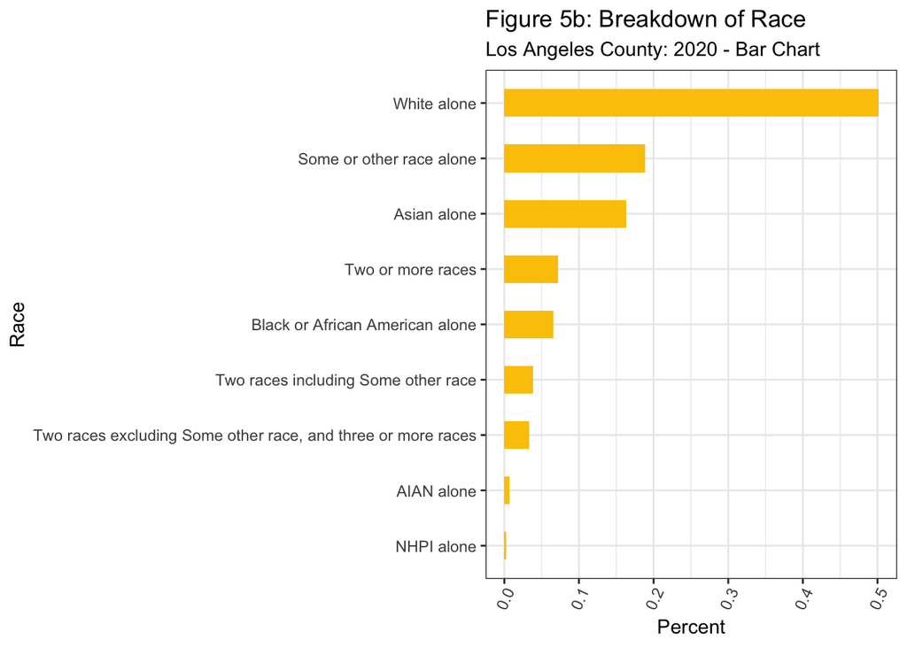

```r
ggplot(la_race, aes(x=pop_share, y=reorder(race_groups, pop_share))) +
  geom_bar(stat="identity", width=.5, fill="#fcc602") +
  labs(title="Figure 5b: Breakdown of Race",
       subtitle="Los Angeles County: 2020 - Bar Chart",
       x = "Percent",
       y = "Race") +
  theme(axis.text.x = element_text(angle=65, vjust=0.6))
```

Figure 5b provides another method of data visualization for the region’s racial breakdown which can be seen through bar charts.